# 受試者內重複量測 ANOVA

Week 12 · Part 2 · 2026-11-26

## 滴完眼藥水，五個時間點怎麼一起比？

- 棒球資料比較不同組的球員。
- 乾眼症研究在五個時間點追蹤同一批病人。
- 同一位病人的前後差可以直接相減。要怎麼一起比較五個時間點的平均呢？

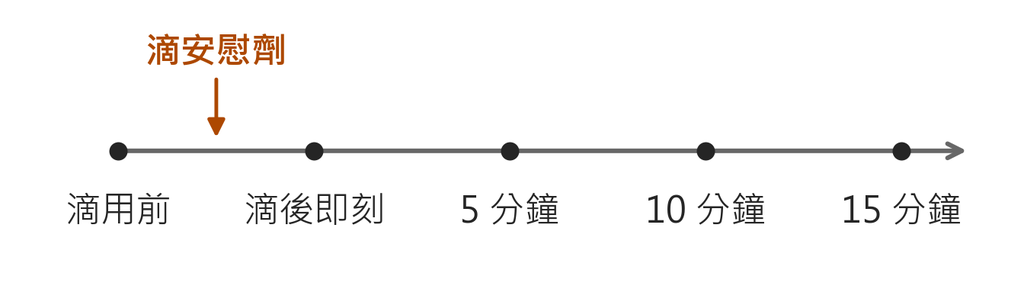

沿箭頭看五個量測時點。橘色標記是滴用安慰劑的時機。

時點依 Rosner 8e Example 12.40、Table 12.24（pp. 614–615）整理。圖上間距表示順序。

## 同一位病人，追蹤五個時間點

- 14 位乾眼症病人都用安慰劑眼藥水。
- 右眼的淚膜能維持幾秒？這是淚膜破裂時間（tear breakup time, TBUT）。
- 每位病人追蹤五個時間點。

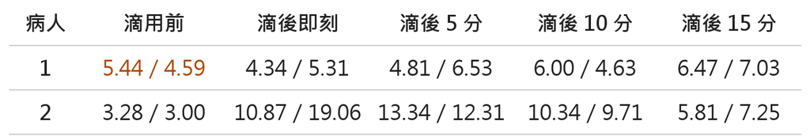

病人 1 和 2 的原始讀值。每格兩個數字都以秒計，橘色標出病人 1 的基線。

- 把同一位病人每格的兩筆讀值取平均，連起五個點就能看出這位病人的變化。

Rosner 8e §12.10，Example 12.40、Table 12.24（pp. 614–615）。完整原始讀值 CSV。

## 一條灰線就是一位病人

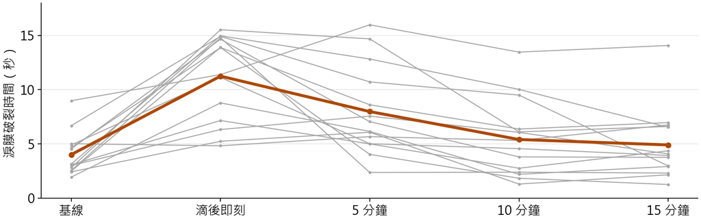

灰線上的每個點，是同一位病人當時兩次量測的平均。橘線是每個時間點把 14 位病人的結果再取平均。

- 同一位病人的五個平均連起來，就是一條灰線。
- 沿著灰線看，滴完後每個人的變化一樣嗎？
- 每位病人在五個時間點都接受量測，所以**時間是受試者內因子（within-subject factor）**。

依 Rosner 8e Table 12.24（p. 615）重繪。橫軸等距排列時間類別。

## 同一批人量五次，和找五批人有什麼差？

- 灰線能連起來，因為五次都量同一個人。
- 假如每次都換一批人，還能這樣比嗎？

| 資料如何取得 | 同一位病人會出現在哪裡？ | 分析方式 |
| --- | --- | --- |
| 每個時間點各找一批病人 | 只出現在其中一欄 | 獨立組單因子 ANOVA |
| 同一批病人追蹤五次 | 同一列跨五個時間欄 | 單因子重複量測變異數分析（one-way repeated-measures ANOVA） |

- 兩種設計都算得出五個時間平均。
- 乾眼研究以病人為獨立觀察單位（independent observational unit），可以沿著同一列相減，直接看**一個人前後變了多少**。

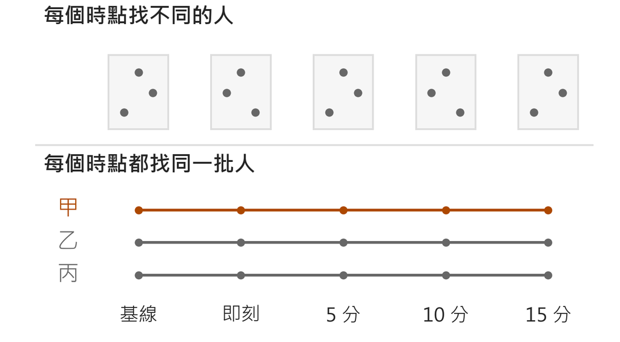

上圖每欄換一組人。下圖一條線連起同一個人的五次量測。

配對圖為本課自製。乾眼資料依 Rosner 8e Table 12.24（p. 615）。

## 同一次相減，兩位病人會得到一樣的數字嗎？

- 表裡已把各時間點的兩筆讀值取平均。
- 用同一位病人的「滴後即刻 − 基線」算前後差。

| 病人 | 基線（秒） | 滴後即刻（秒） |
| --- | --- | --- |
| 1 | 5.015 | 4.825 |
| 2 | 3.140 | 14.965 |

- 病人 1 的淚膜維持時間縮短了，前後差為 $4.825-5.015=-0.190$ 秒。
- 病人 2 的淚膜維持時間變長了，前後差為 $14.965-3.140=11.825$ 秒。
- 用同一人的前後值相減，每人會得到一個差。

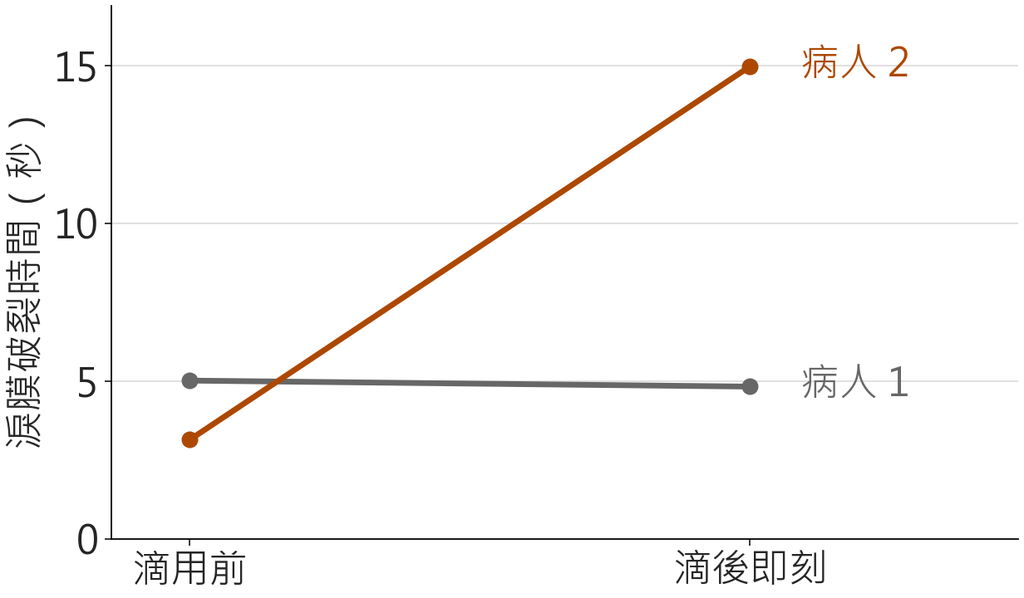

從左到右沿著同一人的線看，病人 1 略降，病人 2 上升。

依 Rosner 8e Table 12.24（p. 615）兩位病人的原始讀值重算。

## 只看滴用前後，每人做一次減法

- 每位病人在各時間點的兩筆讀值先取平均。
- 對病人 $i$，滴用前的平均是 $Y_{i,0}$，滴後即刻的平均是 $Y_{i,1}$。用滴後即刻減滴用前。

  $$d_i = Y_{i,1} - Y_{i,0}.$$
- 14 位病人各提供一個差值。
- 雙尾配對 $t$ 檢定（paired $t$-test）得到 $t(13)\approx 6.42$。滴後即刻的平均淚膜維持時間較長，平均差約是其標準誤的 6.42 倍。
- 只比這兩個時間點時，重複量測 ANOVA 得到 $F=t^2\approx 41.19$，$p$ 值和雙尾配對 $t$ 檢定相同。

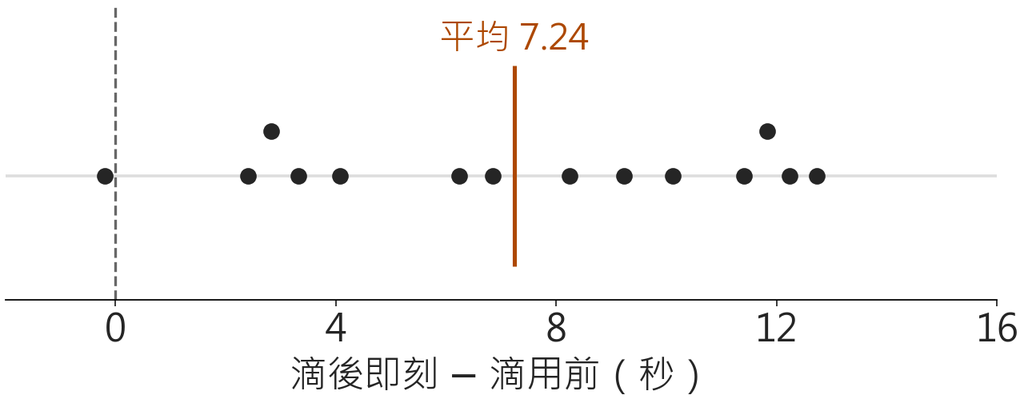

每個點是一位病人的前後差，橘線標出 14 個差值的平均。

IMS 2e Ch. 21（p. 360 起）。數值依 Rosner 8e Table 12.24（p. 615）重算。

## 五個時間平均，能一起比嗎？

- 滴用前和滴後即刻是一對。加上其他三個時間點，一共可以配成十對。
- 五個時間點的母體平均都一樣嗎？這是整體檢定的虛無假設。

$$H_0:\ \mu_{\text{基線}}=\mu_{\text{即刻}}=\mu_{5}=\mu_{10}=\mu_{15}.$$

- 對立假設是至少兩個時間點的母體平均不同。
- 若一對一對檢定，要處理多重比較（multiple comparisons）。
- 整體 $F$ 要用到變異的來源。哪些差異來自病人的平均高低？哪些來自時間變化？

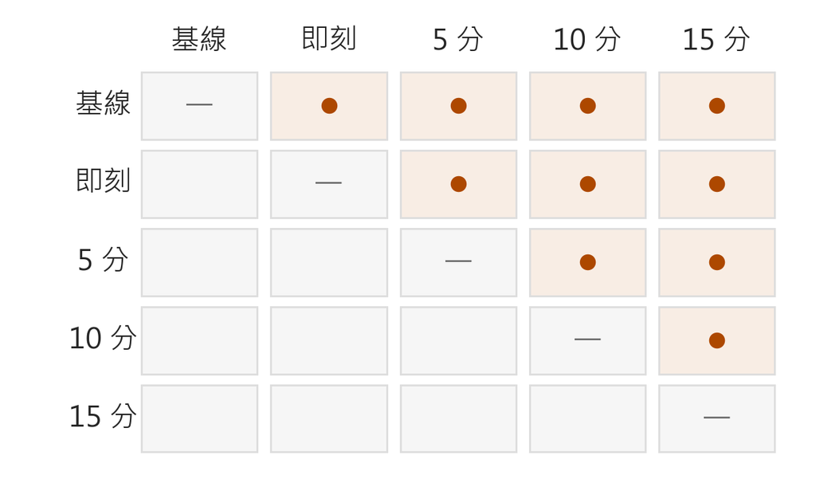

每個橘點是一對不同的時點。只標對角線上方，就會把每一對數一次。

Rosner 8e §12.10，Examples 12.40–12.41（pp. 614–616）。配對矩陣為本課自製。

## 平均都增加 2 秒，圖上還有什麼不同？

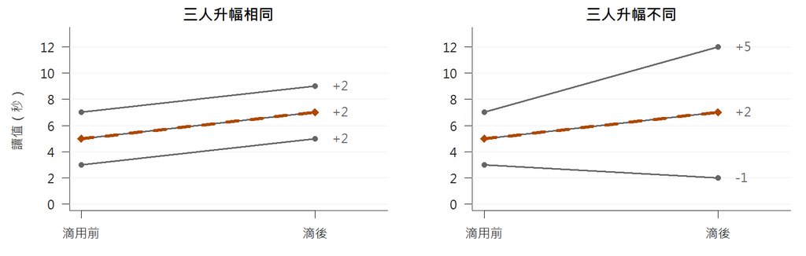

灰線是個人，橘色虛線是三人平均。先比橘線，再看灰線是否跟著同樣的升幅。

- 兩圖的平均都從 5 秒升到 7 秒。
- 左圖每個人都多了 2 秒。
- 右圖有人變短，有人變長，個人的變化有時和平均變化差得更遠。

本課自編示意。兩時點用來顯示共同升幅與個人升幅的差別。

## 灰線的高低和升降，分別代表什麼？

- 有些病人從頭到尾都量得偏高。
- 有些病人滴完後上升很多，也有人變化很小。
- 這兩種差異在平方和（sum of squares, SS）裡怎麼算？

| 怎麼分析 | 扣除時間平均後，還剩哪些平方和？ |
| --- | --- |
| 把五欄當作獨立組 | 組內平方和 776.552 |
| 保留同一位病人的配對 | 病人的平均高低 448.791 ＋ 各人的升降和平均走勢不同 327.761 |

- 保留同一位病人的配對資料，就能從 776.552 中分出病人之間的平均差異。
- 剩下的 327.761 是殘差平方和，用來算時間檢定的分母。

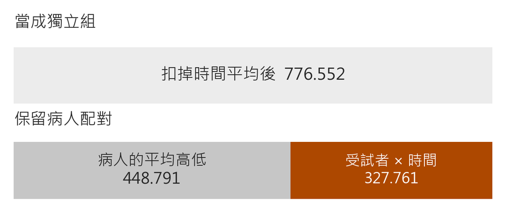

兩條橫條一樣長。保留配對後，可以從中分出病人的平均高低差。

每位病人各時點的平均依 Rosner 8e Table 12.24（p. 615）重算。

## 用三個量寫出病人和時間的差異

- 病人 $i$ 在時間 $j$ 的兩次讀值取平均，記成 $Y_{ij}$。
- 從總平均 $\mu$ 出發，再加上三項。

$$Y_{ij}=\mu + b_i + \tau_j + e_{ij}.$$

| 項目 | 在乾眼資料中的意思 |
| --- | --- |
| $b_i$ | 有些病人的整體 TBUT 偏高或偏低 |
| $\tau_j$ | 這個時間點的平均比總平均高多少或低多少 |
| $e_{ij}$ | 受試者 × 時間的殘差。扣掉病人和時間的平均差後，這一格還差多少。 |

- 圖上最後一段是殘差。知道病人平均和時間平均，就能算出它的大小。

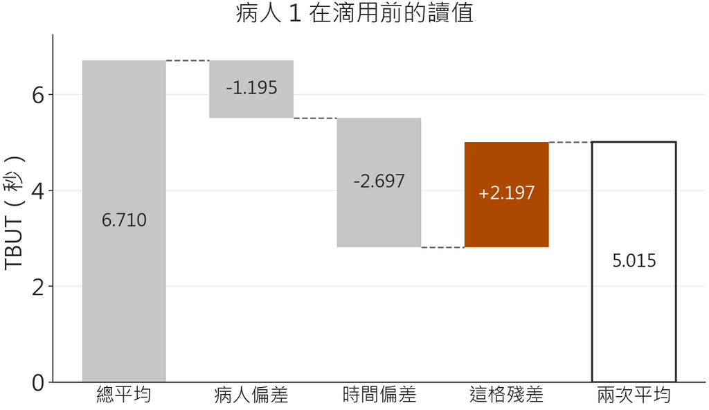

沿著階梯看總平均怎麼加上病人、時間和這一格的殘差，得到 5.015 秒。

Rosner 8e §12.10，Eq. 12.35、Table 12.25（p. 615）。這裡用每位病人在各時間點的兩筆讀值平均來表示。

## 病人 1 的基線，和預測差幾秒？

- 14 位病人各有 5 格。每格 $Y_{ij}$ 是同一人、同一時點的兩筆讀值平均。

**病人 1 的讀值（秒）**

| 時點 | 讀值 1 | 讀值 2 | 格平均 |
| --- | --- | --- | --- |
| 滴用前 | 5.44 | 4.59 | 5.015 |
| 滴後即刻 | 4.34 | 5.31 | 4.825 |
| 滴後 5 分 | 4.81 | 6.53 | 5.670 |
| 滴後 10 分 | 6.00 | 4.63 | 5.315 |
| 滴後 15 分 | 6.47 | 7.03 | 6.750 |

- 五個格平均合計 27.575 秒，除以 5，列平均是 **5.515 秒**。

| 平均 | 用哪些格子算？ | 秒 |
| --- | --- | --- |
| 列平均 $\bar Y_{i\cdot}$ | 病人 1 的 5 格 | 5.515 |
| 欄平均 $\bar Y_{\cdot j}$ | 14 人的基線格 | 4.013 |
| 總平均 $\bar Y_{\cdot\cdot}$ | 全部 70 格 | 6.710 |

$$\begin{aligned}
\widehat Y_{ij} &= \bar Y_{i\cdot} + (\bar Y_{\cdot j}-\bar Y_{\cdot\cdot})\\
r_{ij} &= Y_{ij}-\widehat Y_{ij}
\end{aligned}$$

- 基線預測約為 $5.515+(4.013-6.710)=2.818$ 秒。
- 實際格平均減預測，$5.015-2.818$，殘差約為 **2.197 秒**。

依 Rosner 8e §12.10、Table 12.24（p. 615）的格平均重算。

## 四個平方和怎麼算？三項加起來等於總和嗎？

- 用上一頁的殘差 $r_{ij}$。這裡有 $n=14$ 位病人，每人有 $k=5$ 個時點。

$$\begin{aligned}
SS_{\text{總}} &= \sum_{i,j}(Y_{ij}-\bar Y_{\cdot\cdot})^2 \\
SS_{\text{受試者}} &= k\sum_i(\bar Y_{i\cdot}-\bar Y_{\cdot\cdot})^2
\end{aligned}$$

$$\begin{aligned}
SS_{\text{時間}} &= n\sum_j(\bar Y_{\cdot j}-\bar Y_{\cdot\cdot})^2 \\
SS_{\text{殘差}} &= \sum_{i,j}r_{ij}^{\,2}
\end{aligned}$$

- 每人都有相同的時點，受試者、時間與殘差三項加回總平方和。

$$1258.871 \approx 448.791 + 482.319 + 327.761 \quad (\text{秒}^2)$$

- 扣掉受試者平方和後，時間和殘差合計 **810.080 秒²**。

Rosner 8e §12.10、Table 12.24（pp. 614–616）。平方和由格平均重算，四捨五入至小數第三位。

## 用剛才的平方和算出時間的 $F$

- 各列的平方和除以自由度（degrees of freedom, df），就得到均方（mean square, MS）。

| 變異來源 | 平方和 | 自由度 | 均方 |
| --- | --- | --- | --- |
| 受試者 | 448.791 | 13 | 34.522 |
| 時間 | 482.319 | 4 | 120.580 |
| 受試者 × 時間（殘差） | 327.761 | $13\times4=52$ | 6.303 |
| 總計 | 1258.871 | 69 |  |

- 拿時間均方除以殘差均方。

$$\begin{aligned}
F_{\text{時間}} &= \frac{MS_{\text{時間}}}{MS_{\text{殘差}}} \\
&\approx \frac{120.580}{6.303}\approx19.13
\end{aligned}$$

- 時間均方約是殘差均方的 **19.13 倍**。

依 Rosner 8e Table 12.24 重算，對照 Table 12.27（pp. 615–616）。

## 同樣是前後相減，有些差值比較分散嗎？

- 用 $F=19.13$ 讀 $p$ 值之前，先看一個條件。挑三個時間點，每選一對，就讓 14 位病人各做一次減法。
- 比較這三欄差值有多分散。

| 同一病人的時間差 | 差值在 14 人之間的樣本變異數（秒²） |
| --- | --- |
| 即刻 − 基線 | 17.79 |
| 5 分鐘 − 基線 | 12.33 |
| 5 分鐘 − 即刻 | 21.83 |

- **球形性（sphericity）**說的是任取一對時間點，差值的母體變異數都相同。
- 兩個時間點只有一對，這個條件自然成立。
- 表中三個樣本變異數有高有低，光看它們就能判斷母體的變異數不同嗎？

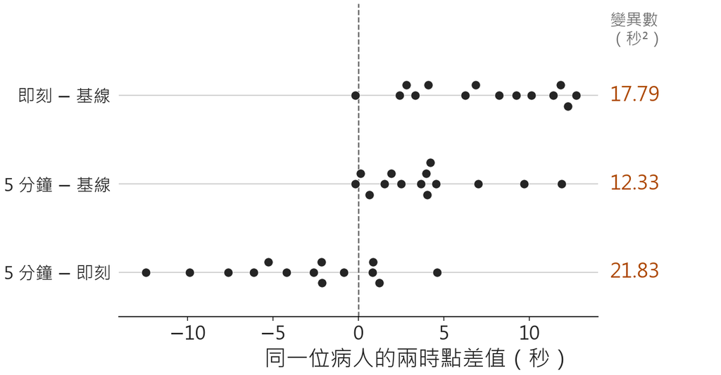

三排共用同一秒數刻度。比較每排散得有多開時，對照右側的樣本變異數。

依 Rosner 8e Table 12.24（p. 615）重算。

## Mauchly 檢定在問什麼？

- 上一頁的三個樣本變異數有大有小。就算母體變異數都一樣，樣本也可能有高有低。
- Mauchly 球形性檢定（`Mauchly's test`）的虛無假設是**每一對時點的母體差值變異數都相同**。
- 用五個時點的量測一起算統計量 $W$。$W$ 越小，資料越偏離球形性。
- 乾眼例得到 $W=.151$、$p=.011$。以 .05 為門檻，資料支持至少兩種配對差的母體變異數不同。

依 Rosner 8e Table 12.24（p. 615）重算。球形性檢定為本課延伸。

## 五個時點怎麼變成四個對比？

- 把 14 人的格平均排成矩陣 `Y`。每列一位病人，每欄一個時點。
- 用四個正交且長度為 1 的時間對比（orthonormal contrasts）。例如第一個是「滴後即刻減基線」再除以 $\sqrt 2$。
- 四個對比的樣本共變異矩陣（covariance matrix）記為 $S$。

$$S\approx
\begin{pmatrix}
\overset{s_{11}}{8.8956} & -2.7424 & -3.5017 & -4.4587\\
-2.7424 & \overset{s_{22}}{8.4190} & 2.8032 & 2.0722\\
-3.5017 & 2.8032 & \overset{s_{33}}{3.3846} & 1.7241\\
-4.4587 & 2.0722 & 1.7241 & \overset{s_{44}}{4.5132}
\end{pmatrix}$$

```r
C <- qr.Q(qr(contr.helmert(ncol(Y))))
S <- cov(Y %*% C)
round(S, 4)
```

- $s_{ij}$ 是第 $i$ 列、第 $j$ 欄。對角線標出的 $s_{11}$ 到 $s_{44}$，是四個對比各自的變異數。
- 例如 $s_{12}=-2.7424$，是第 1 和第 2 個對比的共變異數。

乾眼資料依 Rosner 8e Table 12.24（p. 615）重算。資料與完整 R 指令。

## 從四個對比的共變異矩陣算出 $W$

沿用上一頁的 $S$。把標出的四格相加，就得到跡（trace）。

$$S\approx
\begin{pmatrix}
\overset{s_{11}}{8.8956} & -2.7424 & -3.5017 & -4.4587\\
-2.7424 & \overset{s_{22}}{8.4190} & 2.8032 & 2.0722\\
-3.5017 & 2.8032 & \overset{s_{33}}{3.3846} & 1.7241\\
-4.4587 & 2.0722 & 1.7241 & \overset{s_{44}}{4.5132}
\end{pmatrix}$$

$$\begin{aligned}
\operatorname{tr}(S)&=s_{11}+s_{22}+s_{33}+s_{44}\\
&\approx 8.8956+8.4190+3.3846+4.5132\\
&=25.2124
\end{aligned}$$

- 矩陣有 $q=4$ 欄，所以對角線的平均是 $25.2124/4=6.3031$。
- 行列式（determinant）用整個 $S$ 算，$\det(S)\approx238.3106$。

$$W=\frac{\det(S)}{(\operatorname{tr}(S)/q)^q}
\approx\frac{238.3106}{6.3031^4}\approx .15098$$

```r
q <- ncol(S)
trS <- sum(diag(S))
det(S) / (trS / q)^q
mauchly.test(lm(Y ~ 1), X = ~1)
```

R 用未四捨五入的 $S$ 算得 $W=.15098$、$p=.01104$。

本課依 Rosner 8e Table 12.24（p. 615）重算。R 的檢定使用 `stats::mauchly.test()`。

## 用同一個矩陣算 Greenhouse–Geisser 的 $\hat\epsilon$

- 沿用四個對比的 $S$。先把 $S$ 的各個元素平方後加總，得到約 $291.4099$。
- $S$ 對稱，這個加總等於先做矩陣乘法 $S\times S$，再取跡。

$$\hat\epsilon_{\mathrm{GG}}
=\frac{\bigl(\operatorname{tr}(S)\bigr)^2}
{q\,\operatorname{tr}(S^2)}
\approx\frac{25.2124^2}{4\times291.4099}
\approx .5453$$

```r
eps_GG <- trS^2 / (q * sum(S^2))
eps_GG
anova(fit, X = ~1, test = "Spherical")
```

- R 輸出中的 `Greenhouse-Geisser epsilon` 約為 .5453。下一頁用它調整自由度。

本課依 Rosner 8e Table 12.24（p. 615）重算。R 的球形性校正使用 `stats::anova()` 的多變項線性模型方法。

## Greenhouse–Geisser 校正改了什麼？

- 球形性不成立時，照原本的自由度讀 $p$ 值，可能太容易判出時間差異。
- 用剛才從對比共變異矩陣算出的 $\hat\epsilon$。越接近 1，調整越少。
- 乾眼例的 $\hat\epsilon\approx.5453$。分子與分母的自由度都乘上它。

$$(4,\ 52)\quad \xrightarrow{\ \times\, .5453\ }\quad (2.18,\ 28.36)$$

- 保留 $F=19.13$。用調整後的 $F$ 分布找右尾機率。

依 Rosner 8e Table 12.24（p. 615）重算。自由度校正為本課延伸。

## 校正後，時間差異還看得到嗎？

- 同一個 $F=19.13$，用不同的自由度讀出不同的 $p$ 值。

| 檢定 | $F$ | 自由度 | $p$ 值 |
| --- | --- | --- | --- |
| 經典時間檢定 | 19.13 | 4、52 | $9.99\times 10^{-10}$ |
| Greenhouse–Geisser 校正 | 19.13 | 2.18、28.36 | $3.43\times 10^{-6}$ |

- 校正後，資料仍支持**安慰劑組的平均 TBUT 隨時間改變**。
- 五個平均裡至少有兩個不同。接著只看 15 分鐘和基線，估計這一對的對比（contrast）。

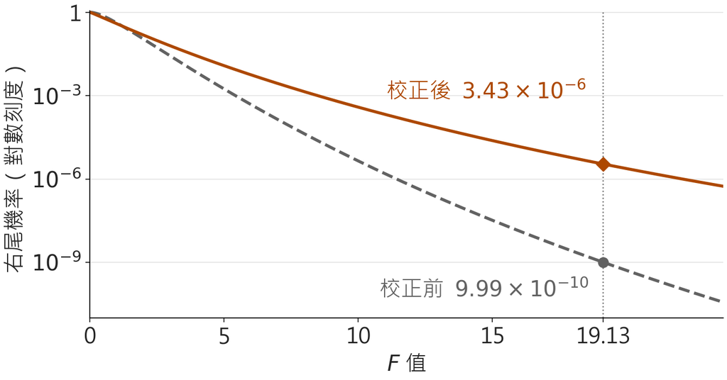

沿著同一個 F 值的垂線往上看，灰線和橘線的右尾機率不同。

Rosner 8e §12.10，Example 12.41、Table 12.27（pp. 616–617）。表內精確 $p$ 值依原書資料重算。

## 練習｜15 分鐘後，比滴用前多了幾秒？

- 整體檢定支持至少兩個時間點的平均不同。
- 要比 15 分鐘和基線，每位病人要拿哪兩個值相減？
- 每人用「15 分鐘的兩筆平均 − 基線的兩筆平均」。
- 用這 14 個差值算配對 $t$ 區間（自由度 13）。
- 平均差為 **0.89 秒**。這一對的 95% 配對信賴區間是 **−0.45 到 2.23 秒**，沒有做多重比較校正。
- 若看過資料才從十對中挑出這一對，就把結果當作探索。若一起檢定十對，可用 Bonferroni 處理多重比較。
- 這些數字只描述安慰劑組。要估計治療效益，還需要和治療組比較。

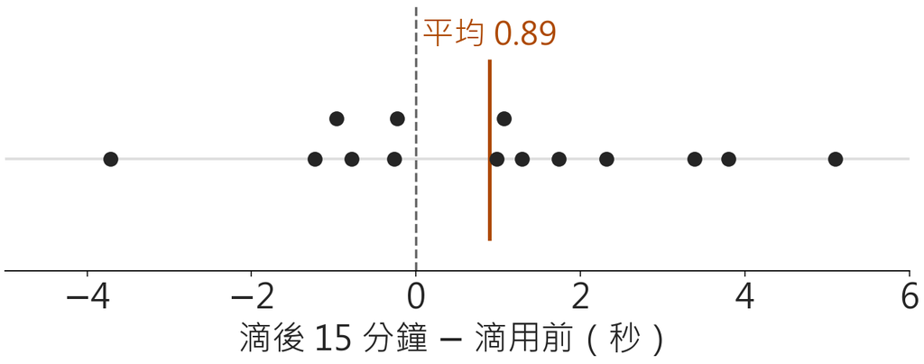

黑點是個人差值，橘線是平均。零線兩側都有病人。

依 Rosner 8e Table 12.24（p. 615）重算。

## 平均多 0.89 秒，可以說已經回到基線嗎？

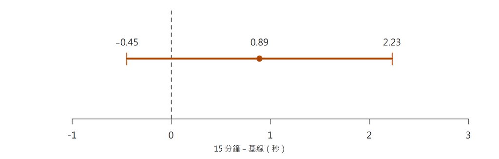

圓點是平均差，橘線是這一對時間的 95% 信賴區間。灰色虛線標出差為零的位置。

- 區間涵蓋平均變短、沒有差和平均變長。
- 要判斷兩個時間點的平均是否夠接近，得先訂出實務上能接受的差距。
- 若一起看五個時間點，時間這一項占了多少變異？

由 Rosner 8e Table 12.24（p. 615）的 14 個配對差重算。

## 從圖上圈出部分 η² 的分母

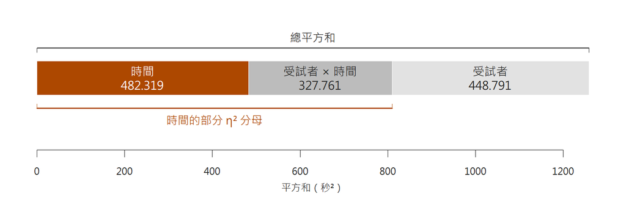

橘色是時間平方和。上方括線涵蓋總平方和，下方只括住計入部分 η² 的兩段。

- 上方括線是全部變異，用它當分母，就能算出時間占全部變異多少。
- 下方括線扣掉病人平均高低的差異，用它當分母，就能算出時間占剩餘變異多少。

依 Rosner 8e Table 12.24（p. 615）的格平均重算。各段寬度與平方和成比例。

## 乾眼資料的部分 η²，分母要算進哪些變異？

- 乾眼資料的總平方和包含病人的平均高低差 448.791。
- 扣掉這一項，分母就剩下**時間和受試者 × 時間的平方和**。
- 這樣算出的是時間的部分 eta 平方（partial eta squared，$\eta_p^2$）。

$$\eta_p^2
=\frac{SS_{\text{時間}}}{SS_{\text{時間}}+SS_{\text{受試者}\times\text{時間}}}
=\frac{482.319}{482.319+327.761}\approx .595.$$

- 扣掉病人的平均高低差後，時間占安慰劑組剩餘變異的 59.5%。
- 棒球的 2.3% 用總變異當分母。總平方和只有組間和組內兩項，所以兩種 eta 平方算出來一樣。
- 換成三個時點的反應時間例。用同一張表找找看，時間 $F$ 和部分 $\eta^2$ 各用哪一欄。

依 Rosner 8e Tables 12.24、12.27（pp. 615–616）另算。本課效果量延伸。

## 同一批人量三次，時間 $F$ 和部分 $\eta^2$ 怎麼算？

- 同一批 12 人在三個時間點接受反應時間量測。假設傳統時間 $F$ 檢定的條件成立。
- 分子和分母要各選哪一列的均方？

| 來源 | 平方和 | 自由度 | 均方 |
| --- | --- | --- | --- |
| 時間 | 18 | 2 | 9 |
| 受試者 | 66 | 11 | 6 |
| 受試者 × 時間 | 44 | 22 | 2 |

- $F(2,22)=9/2=4.5$，$p\approx .023$，支持至少兩個時間點的母體平均反應時間不同。
- 部分 $\eta^2$ 改看平方和欄，分母只加時間與受試者 × 時間：$\eta_p^2=18/(18+44)\approx .29$。
- 扣掉受試者的平均高低差後，時間占剩下的樣本變異約 29%。

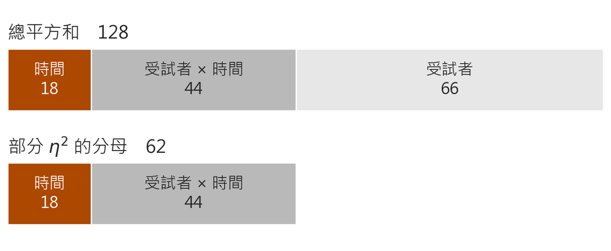

下方橫條只留時間和受試者 × 時間。橘色占這一條約 29%。

本課自編重複量測案例。表格與檢定摘要是教學用數字。

## 兩次都容易量得偏高，相減後會怎樣？

- 兩個例子都從收完資料的表算效果量。要規劃下一次追蹤研究，還要知道同一人的讀值會怎麼一起變。
- 假設前、後兩次量測的變異數都是 4 秒²，共變異（covariance）不同時，差值的變異數會怎麼變？

| 兩次讀值的關係 | 差值變異數（秒²） |
| --- | --- |
| 共變異為 0 | $4+4-2(0)=8$ |
| 共變異為 3 秒² | $4+4-2(3)=2$ |

- 同一人的兩次讀值如果常一起偏高或偏低，相減時，一部分共同的波動就會抵銷。
- 追蹤五次時，要考慮所有時點彼此的共變異。

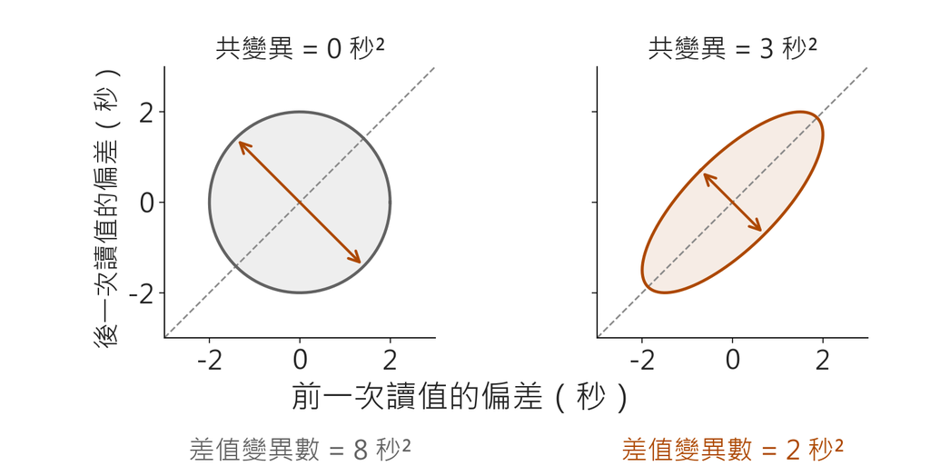

兩邊用同一尺度。沿橘色箭頭看差值的方向，正共變異時分散較小。

本課自編兩時點示意。以差值變異數公式說明共變異如何影響規劃。

## 規劃時，哪些數字要一起寫出來？

- 同一人的讀值怎麼一起變，會影響前後差的波動。
- 規劃新研究時，先寫下要檢定的差異、顯著水準和目標檢定力，再依設計列出變異的假設。

## Slido｜Part 2 受試者內重複量測 ANOVA

[figure not shown]

Week 12 Part 2 Slido 作答 QR code

[開啟 Slido 作答頁](https://qr.sli.do/5HDVvewXzbksXLBFjcjX8S) · 活動代碼 **2773247**